# Confirmatory Factor Analysis

ChatGPT 4o

2024-11-20

## 1 起源

确认性因子分析（Confirmatory Factor Analysis, CFA）是一种用于验证理论模型的统计方法，最早由心理学家J·L·卡蒂尔（J.L. Cattell）和R·B·斯皮尔曼（R.B. Spearman）在20世纪中期发展起来。CFA最初用于心理学和社会科学领域，通过验证预设因子结构来评估量表和测试的结构效度。与探索性因子分析（EFA）不同，CFA在事先明确的理论基础上验证数据是否符合特定的因子模型。

## 2 原理

确认性因子分析的原理是通过构建因子模型，将观测变量与潜在因子关联起来，并评估模型的拟合程度。CFA假设观测变量可以由潜在因子解释，模型的目标是找到使得模型拟合数据的参数估计值。

CFA的基本模型形式为：

$$X = \Lambda \xi + \epsilon$$

其中，$X$ 表示观测变量，$\xi$ 表示潜在因子，$\Lambda$ 表示因子载荷矩阵，$\epsilon$ 表示误差项。CFA通过最大似然估计等方法估计因子载荷，并使用拟合度指标评估模型与数据的匹配程度。

## 3 适用范围

确认性因子分析适用于以下情况：

- **理论验证**：当研究者已有明确的理论或假设，期望验证观测数据是否符合预设的因子结构时，CFA非常适合。
- **量表和测试的验证**：用于验证量表和心理测量工具的结构效度，评估其因子结构是否合理。
- **探索性因子分析的后续验证**：当EFA发现了因子结构后，可以使用CFA对其进行进一步验证。

## 4 应用情境

确认性因子分析在多个领域都有广泛的应用，例如：

- **心理学**：用于验证心理测试的因子结构，如人格量表、情绪问卷等的结构效度。
- **教育学**：评估学业成就测验的因子结构，确保量表测量的内容符合教育理论。
- **社会科学**：验证社会调查问卷中的因子结构，以评估问卷的信度和效度。
- **医学研究**：用于验证健康量表和症状评估工具的因子结构，以确保其科学性和准确性。

## 5 优缺点

### 优点

- **验证理论模型**：CFA能够基于理论模型对数据进行验证，是验证性分析的有效工具。
- **提供拟合度指标**：CFA提供多种拟合度指标，用于评估模型与数据的匹配程度，有助于模型的改进。
- **模型复杂度高**：CFA能够处理复杂的因子模型，包括多个因子和因子之间的相关关系。

### 缺点

- **对理论依赖性强**：CFA基于明确的理论假设，如果理论不合理，模型结果可能误导研究者。
- **对样本量要求高**：CFA通常需要较大的样本量来保证模型的稳定性和拟合结果的可靠性。
- **对数据的要求较高**：CFA要求数据满足正态分布、线性关系等假设，违背这些假设可能导致结果不准确。

## 6 在R中的实现及结果解释

在R中，可以使用`lavaan`包中的`cfa()`函数进行确认性因子分析。以下是一个实现CFA的示例：

```r
# 加载必要的包
library(lavaan)
```

```r
library(ggplot2)

# 示例数据：生成假设数据
set.seed(123)
data <- data.frame(
  V1 = rnorm(100, mean = 5, sd = 2),
  V2 = rnorm(100, mean = 3, sd = 1),
  V3 = rnorm(100, mean = 4, sd = 1.5),
  V4 = rnorm(100, mean = 6, sd = 2)
)

# 定义因子模型
model <- '
  # 因子结构
  F1 =~ V1 + V2 + V3
  F2 =~ V3 + V4
'

# 进行确认性因子分析
fit <- cfa(model, data = data)
# 输出CFA结果
summary(fit, fit.measures = TRUE)
```

```
## lavaan 0.6-19 ended normally after 55 iterations
##
##   Estimator                                         ML
##   Optimization method                           NLMINB
##   Number of model parameters                        10
##
##   Number of observations                           100
##
## Model Test User Model:
##
##   Test statistic                                 0.090
##   Degrees of freedom                                 0
##
## Model Test Baseline Model:
##
##   Test statistic                                 2.629
##   Degrees of freedom                                 6
##   P-value                                        0.854
##
## User Model versus Baseline Model:
##
##   Comparative Fit Index (CFI)                    0.000
##   Tucker-Lewis Index (TLI)                       1.000
##
## Loglikelihood and Information Criteria:
##
##   Loglikelihood user model (H0)               -729.656
##   Loglikelihood unrestricted model (H1)       -729.610
##
##   Akaike (AIC)                                1479.311
##   Bayesian (BIC)                              1505.363
##   Sample-size adjusted Bayesian (SABIC)       1473.780
##
## Root Mean Square Error of Approximation:
##
##   RMSEA                                          0.000
##   90 Percent confidence interval - lower         0.000
##   90 Percent confidence interval - upper         0.000
##   P-value H_0: RMSEA <= 0.050                       NA
##   P-value H_0: RMSEA >= 0.080                       NA
```

[output cut: 19 more lines]

```
##     V4               -0.725       NA
##
## Covariances:
##                    Estimate  Std.Err  z-value  P(>|z|)
##   F1 ~~
##     F2                0.268       NA
##
## Variances:
##                    Estimate  Std.Err  z-value  P(>|z|)
##    .V1                2.815       NA
##    .V2                0.910       NA
##    .V3                1.433       NA
##    .V4                4.005       NA
##     F1                0.485       NA
##     F2                0.509       NA
```

### 结果解释

- **因子载荷**：输出结果中包含因子载荷的估计值、标准误差和显著性检验结果。因子载荷表示每个观测变量在相应因子上的权重。
- **拟合度指标**：CFA的拟合度指标（如CFI、TLI、RMSEA等）用于评估模型对数据的拟合效果。如果这些拟合度指标显示良好（例如CFI > 0.9，RMSEA < 0.08），则说明模型与数据的匹配程度较好。

### 结果的可视化

可以使用`semPlot`包中的`semPaths()`函数对CFA的结果进行可视化，直观展示因子与观测变量之间的关系。

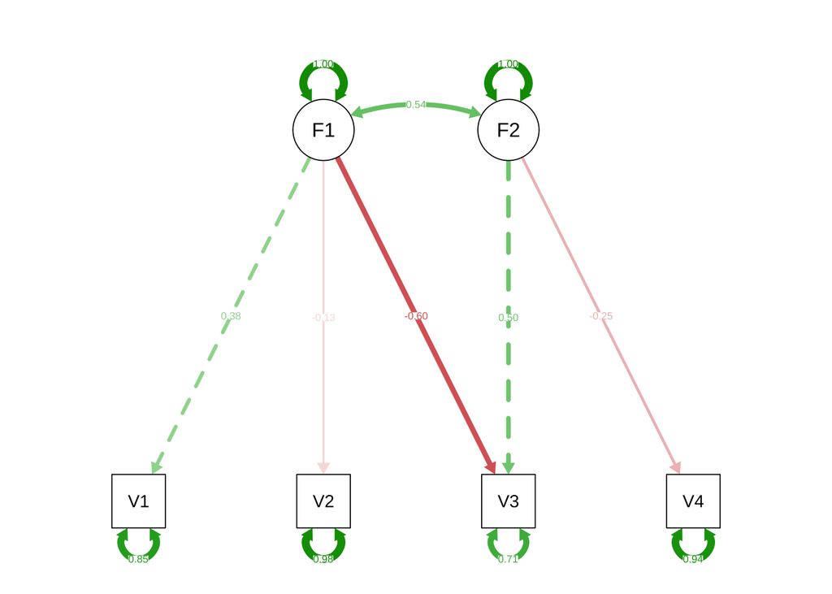

```r
# 安装并加载semPlot包
if (!requireNamespace("semPlot", quietly = TRUE)) {
  install.packages("semPlot")
}
library(semPlot)

# 绘制因子结构图
semPaths(fit, what = "std", layout = "tree", title = TRUE, nCharNodes = 0, sizeMan = 7, sizeInt = 5)
```

上述代码将生成因子结构图，展示因子与观测变量之间的关系，因子载荷标注在连接线上，使得模型的解释更加直观。

## 7 小结

- 确认性因子分析是一种用于验证理论模型的统计方法，能够基于预设的因子结构对观测数据进行验证。
- 适用于量表验证、测试工具的结构效度评估，以及理论验证等场景。
- 具有验证理论模型、提供拟合度指标的优点，但对理论和数据的要求较高，需谨慎处理。
- 可以通过R中的`cfa()`函数实现确认性因子分析，并结合可视化工具直观展示因子结构。
- 在心理学、教育学、社会科学和医学研究等领域，CFA是一种重要的工具，用于确保测量工具的科学性和可靠性。